# FordGobike

## by (Hager Mohamed)

## Investigation Overview

> In this investigation, I wanted to look at to the usage, I focused on some main features such as time, gender, duration, age and user type to analyze and understand the usage of FordGobike project and to know what's stregnth and weakness of this project

## Dataset Overview

> This document explains a dataset containing the trip data of the ford gobike approximately 183,412 record accros Feb 2019.

## (Visualization 1)

> In this data we have 2 different types of users
> 1. customer
> 2. subscriber this visualization shows the percentage of each type usage

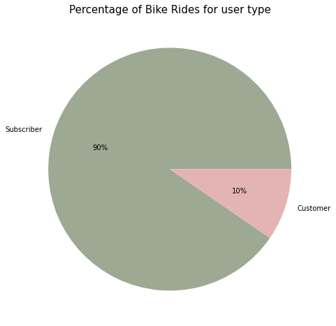

```python
colors = ["#9DA993", "#E4B4B4"]
plt.figure(figsize=(8,8))
plt.pie(new_df.user_type.value_counts(), labels=new_df.user_type.value_counts().keys(), colors=colors,autopct='%1.0f%%')
plt.title("Percentage of Bike Rides for user type", fontsize=15)

plt.show()
```

## (Visualization 2)

> The user types we have in this data are from different genders Male,Female and other and here is the percetange of participation for each gender

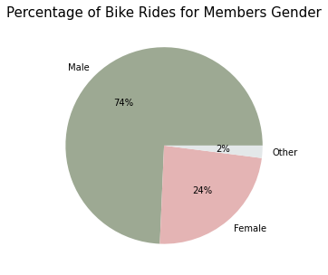

```python
colors = ["#9DA993", "#E4B4B4", "#E3E8E9"]
plt.figure(figsize=(5,5))
plt.pie(new_df.member_gender.value_counts(), labels=new_df.member_gender.value_counts().keys(), colors=colors,autopct='%1.0f%%')
plt.title("Percentage of Bike Rides for Members Gender", fontsize=15)

plt.show()
```

## (Visualization 3)

> Here is an investigation about frequency of the ages uses fordGobike

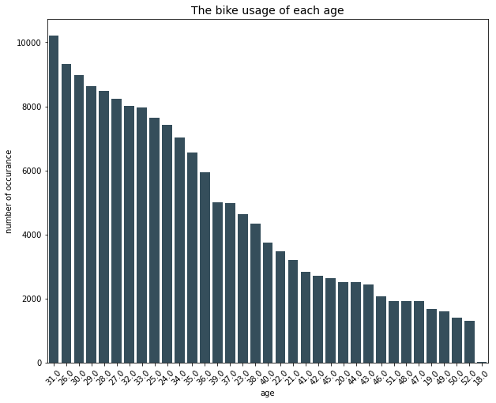

```python
fig, ax = plt.subplots(figsize=(10, 8))
age=sb.countplot(data=new_df, x='member_age', order=new_df.member_age.value_counts(ascending=False).index,color = "#2F5061",ax=ax)
age.set_xticklabels(labels=new_df.member_age.value_counts(ascending=False).keys(),rotation=45,size=10)
age.set_yticklabels(labels=[i for i in range(0,10500,2000)],size=10)
age.set_xlabel('age', fontsize=10)
age.set_ylabel('number of occurance', fontsize=10)
age.set_title('The bike usage of each age', fontsize=14);
```

## (Visualization 4)

> Here is an investigation about the daily usage of Bike Rides Per Gender

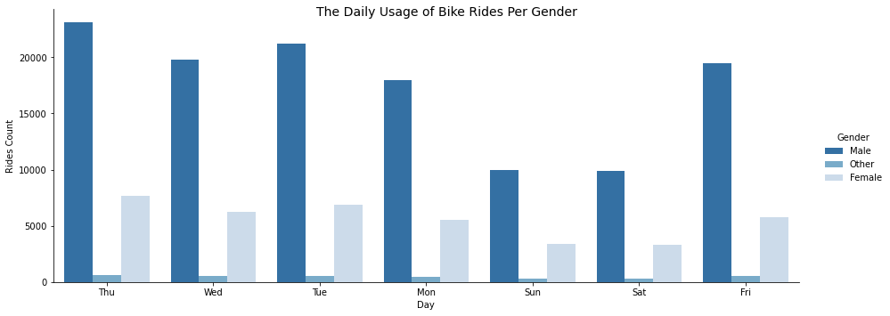

```python
day_to_gender = sb.catplot(data=new_df, x='start_day', hue='member_gender', kind='count',aspect=20.7/8.27,palette='Blues_r')
day_to_gender.set_axis_labels('Day', 'Rides Count')
day_to_gender._legend.set_title('Gender')
day_to_gender.fig.suptitle('The Daily Usage of Bike Rides Per Gender', fontsize=14);
```

## (Visualization 5)

> Here is an investigation about the Daily Usage of Bike Rides per User Type Based on Gender

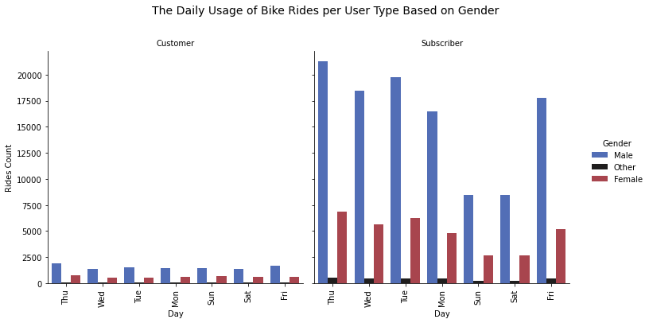

```python
type_gender_usage = sb.catplot(data=new_df, x='start_day', col="user_type", hue='member_gender', kind='count'
                               ,palette='icefire')

type_gender_usage.set_axis_labels('Day', 'Rides Count')
type_gender_usage.set_xticklabels(rotation=90)
type_gender_usage._legend.set_title('Gender')
type_gender_usage.set_titles('{col_name}')
type_gender_usage.fig.suptitle('The Daily Usage of Bike Rides per User Type Based on Gender', fontsize=14, y=1.09);
```

## (Visualization 6)

> Here is an investigation about the hourly Usage of Bike Rides per User Type Based on Gender

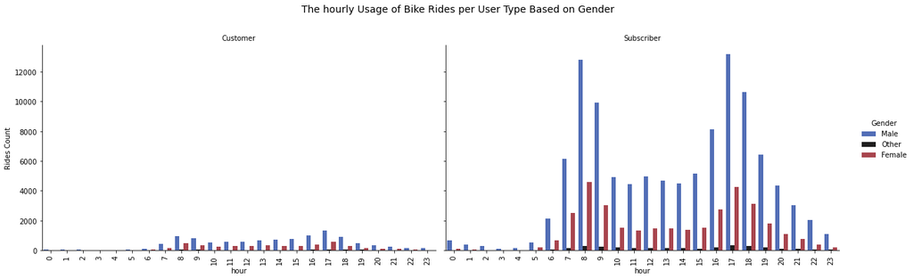

```python
type_gender_usage = sb.catplot(data=new_df, x='start_hour', col="user_type", hue='member_gender',aspect=20/12, kind='count'
                               ,palette='icefire')

type_gender_usage.set_axis_labels('hour', 'Rides Count')
type_gender_usage.set_xticklabels(rotation=90)
type_gender_usage._legend.set_title('Gender')
type_gender_usage.set_titles('{col_name}')
type_gender_usage.fig.suptitle('The hourly Usage of Bike Rides per User Type Based on Gender', fontsize=14, y=1.09);
```